# Coil Training for Ball-in-Box

```r
library(neuralcoil)
```

# Parameterizing Coils to Represent Practical Systems

In this vignette we will explore how coils can be trained to emulate conservative probabilistic systems. For this example let us consider a ball bouncing in a 1 dimensional box, where the original position and velocity of the ball are uncertain. If we partition the box into 4 segments, we can simulate many different instances of the ball bouncing in the box to develop a time-evolving discrete probability distribution of the ball’s position:

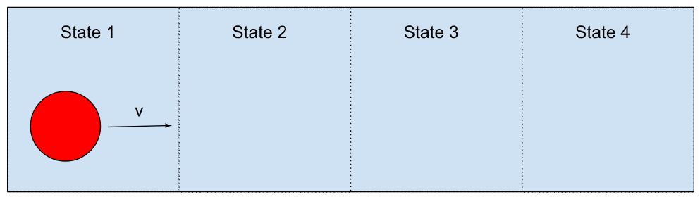

Ball-In-Box Representation

The results of such a simulation are stored in the exampledata_ballinbox dataset:

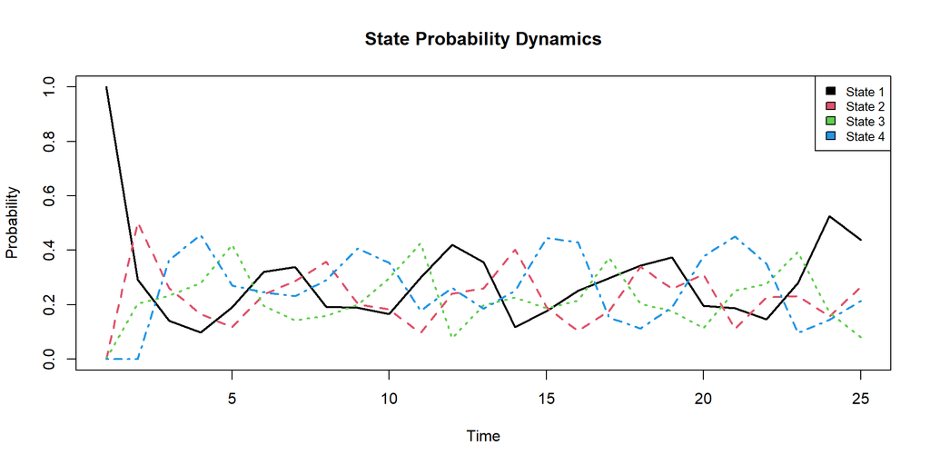

```r
#Load in Ball-in-Box data:
data("exampledata_ballinbox")
out_goal=as.numeric(exampledata_ballinbox)


matplot(exampledata_ballinbox,type="l",lwd=2,xlab = "Time",ylab="Probability",main="State Probability Dynamics")
legend("topright", paste("State",1:4),col=seq_len(4),cex=0.8,fill=seq_len(dim(exampledata_ballinbox)[2]))
```

We will attempt to replicate these probability dynamics by parameterizing a coil using a Particle Swarm Optimizer (PSO). In this case, we will not worry much about forcing locality or inertia; our hope is the PSO will be able to determine these characteristics through optimization.

```r
#User Selections----
n.s=dim(exampledata_ballinbox)[2]#number of states
sym=F   #Parameter Symmetry
loc=F #Locality
cont=T #Parameter Physicality Controls
sub.num=1 #Number of conserved subgroups
vfara_inert=1 #inertia
vfara_init=1 #initial inertia
Tlen=dim(exampledata_ballinbox)[1] #Steps to run coil

buildcoil(n.s,sym=F)

#Number of needed parameters
L=dim(CoilVals)[1]*2+3+n.s*2
```

We can now train our particle swarm optimizer. This will most likely take a while so we can use some previously found weights.

```r
retrain=F

if (retrain){
  #Particle Swarm Optimizer
n.part=100#number of particles

w=0.9 #velocity factor
g_p=0.4#position influence factor
g_g=0.4#swarm influence factor

initialize_swarm_full(n.part,L,setrots=c(2,5,5))

for (itt in 1:10){
  if (itt<400){
    slseq=array(matrix(seq(1:length(out_goal)),ncol=n.s)[1:round(Tlen/2),])
    #slseq=c(1:15,26:36,51:61,76:86)
  }else{
    slseq=1:length(out_goal)
  }
  #slseq=1:length(out_goal)

  step_swarm_full(n.part,L,setrots=c(2,5,5))
  matplot(t(outmat),col="grey",lty=1,type="l")
  lines(out_goal,col="blue")
  print(itt)
}
 best_weights=best_p[which.min(apply(best_p_res,1,function(x)optf(x,out_goal,slseq))),]
}else{
  best_weights=readRDS("../results/ballinbox_weights_final.RdA")
}
coil_out=pop_coil_full(best_weights)

Pmat=coil_out[[1]]
complex_states=coil_out[[2]]
```

Let us overlay the discrete probability dynamics produced by our coil atop the simulated probability dynamics.

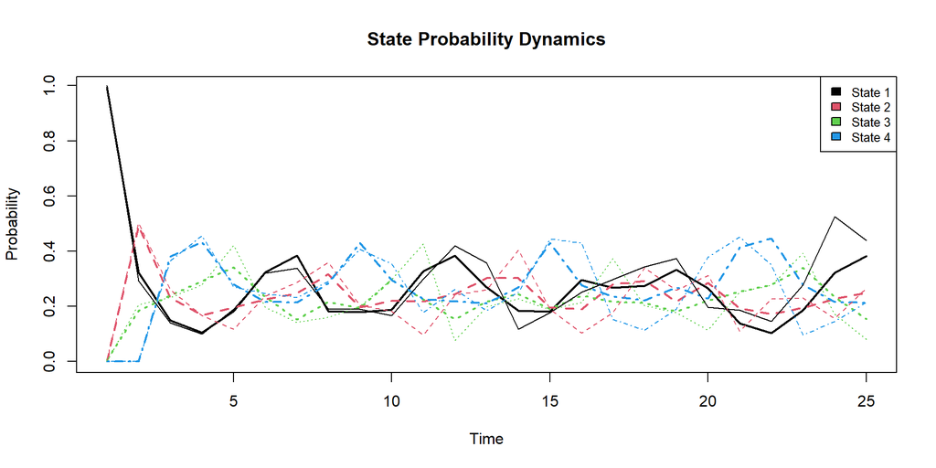

```r
matplot(Pmat,type="l",lwd=2,xlab = "Time",ylab="Probability",main="State Probability Dynamics")
matlines(exampledata_ballinbox)
legend("topright", paste("State",1:4),col=seq_len(4),cex=0.8,fill=seq_len(dim(exampledata_ballinbox)[2]))
```

Here we can see that coils can represent probabilistic dynamics of physics-based systems with some training. We can compare these dynamics a bit more clearly by splitting out our graphics by state.

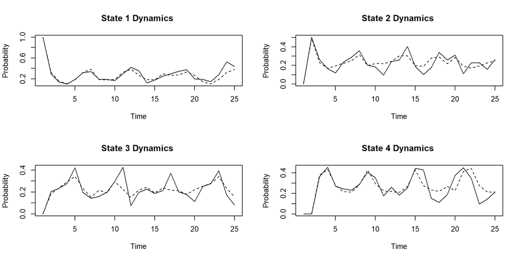

```r
par(mfrow = c(2, 2))
for (iP in 1:dim(Pmat)[2]){

  plot(exampledata_ballinbox[,iP],type="l",xlab="Time",ylab="Probability",main = paste("State",iP,"Dynamics "))
  lines(Pmat[,iP],lty=2)
}
```

```r
par(mfrow = c(1,1))
```

To visualize the probability flowing between discrete states we can animate the probability as well as the real and complex components of the coil.

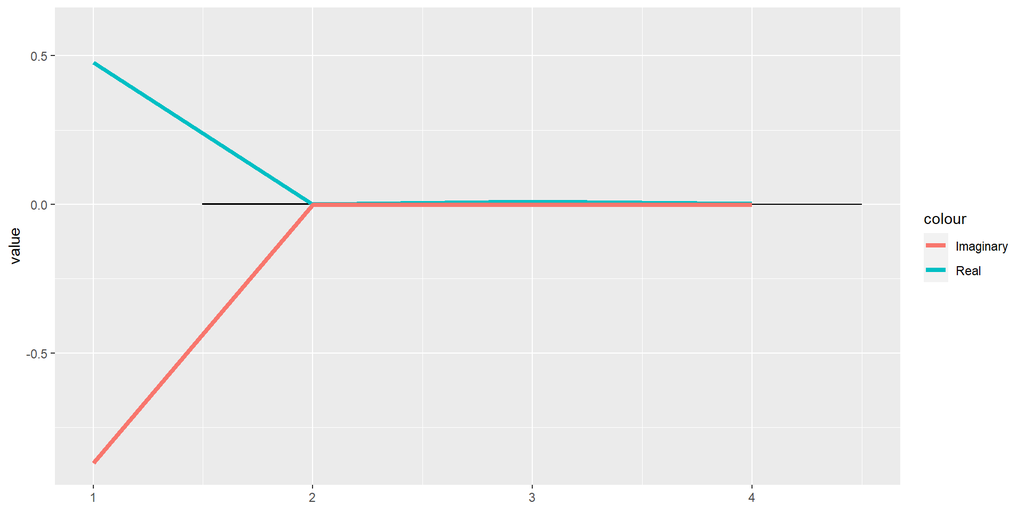

```r
library(ggplot2)

ylims=c(min(Re(complex_states),Im(complex_states)),max(Re(complex_states),Im(complex_states)))
ylims[2]=ylims[2]+0.1

for (itt in 1:Tlen){
  datin=data.frame(state=c(1,2,3,4),value=Pmat[itt,],Real=Re(complex_states)[itt,],Imaginary=Im(complex_states)[itt,])
  p <- ggplot(datin,
                 aes(state,value)) +
    geom_bar(stat = "identity",width=1,fill="grey",color="black")+
    geom_line(aes(x=as.numeric(state),y=Real,col="Real"),size=1.5)+
    geom_line(aes(x=as.numeric(state),y=Imaginary,col="Imaginary"),size=1.5)+
    theme(axis.title.x = element_blank())+
    scale_y_continuous(limits = ylims)
  print(p)
}
```

A question that arises naturally is why are coils so difficult to train? Aside from the sheer number of probabilistic tranisition values, coils also exhibit a hypersensitivity to their rotation. In this case we are fixing the rotation values, but let’s see how the coil dynamics change when just changing the rotation slightly.

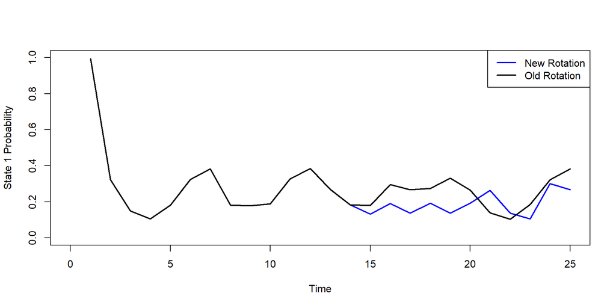

```r
new_weights=best_weights
rdim=dim(CoilVals)[1]
new_weights[(rdim*2+1):(rdim*2+3)]=c(2,5.00001,5)
state.sel=1
matplot(pop_coil_full(new_weights)[[1]][,state.sel],pch=1,type="l",xlim=c(0,(Tlen)),lwd=2,ylim=c(0,1),xlab="Time",ylab=paste("State",state.sel,"Probability"),col="blue")

matlines(Pmat[,state.sel],lwd=2,type="l",xlim=c(0,(Tlen)),xlab="Time",ylab="P(s)",col="black")
legend("topright",col=c("blue","black"),c("New Rotation","Old Rotation"),lwd=2)
```